# Statistical Analyses for Van Meter et al 2016

# Introduction

Data set, statistical analyses, graphics and inference concerning effect of organic carbon in soil on dermal bioconcentration in amphibians. Analytes include active ingredients for commonly used pesticides (atrazine, imidacloprid, fipronil, triadimefon, pendimethalin).

# Distribution

This page is public at: http://rpubs.com/puruckertom/rvm2016

The git repo holding this code is available at: https://github.com/puruckertom/VanMeteretal2016_ple_v_ols

# Computational environment

Version and installed libraries.

```r
R.Version()$version.string
```

```
## [1] "R version 3.2.3 (2015-12-10)"
```

```r
Sys.info()[4]
```

```
##        nodename
## "stp-air.local"
```

```r
#check to see if needed packages are installed
list.of.packages <- c("ggplot2", "dplyr")
new.packages <- list.of.packages[!(list.of.packages %in% installed.packages()[,"Package"])]
if(length(new.packages)) install.packages(new.packages)
#load relevant packages
library(MASS)
library(dplyr, warn.conflicts = FALSE)
library(ggplot2)
```

# Experimental data

Original file with analytical data: https://github.com/puruckertom/VanMeteretal2016_ple_v_ols/blob/master/RDATA.csv

```r
##################
#the data sets
##################
#everything
file.exists(paste(frogsoildir,"RDATA.csv",sep=""))
```

```
## [1] TRUE
```

```r
frog.soil <- read.table(paste(frogsoildir,"RDATA.csv",sep=""), header = TRUE, sep = ",")
str(frog.soil)
```

```
## 'data.frame':    264 obs. of  11 variables:
##  $ Day        : int  2 2 2 2 2 2 2 2 2 2 ...
##  $ Row        : int  1 1 3 5 6 7 1 2 2 4 ...
##  $ Column     : Factor w/ 10 levels "","A","B","C",..: 2 9 4 4 7 3 3 7 10 3 ...
##  $ Pesticide  : Factor w/ 17 levels "ATZ","ATZDEA",..: 4 4 4 4 4 4 4 4 4 4 ...
##  $ SoilType   : Factor w/ 2 levels "OLS","PLE": 2 2 2 2 2 2 1 1 1 1 ...
##  $ BodyBurden : num  0.337 1.227 0.701 0.367 0.352 ...
##  $ Soil       : num  22.9 39.6 19.1 16.6 28.5 ...
##  $ Weight     : num  13.18 15.87 8.39 14.54 16.43 ...
##  $ Total      : int  1 1 1 1 1 1 1 1 1 1 ...
##  $ Formulation: int  0 0 0 0 0 0 0 0 0 0 ...
##  $ Parent     : int  1 1 1 1 1 1 1 1 1 1 ...
```

Modifying data set to create factors for ANOVA, calculate BCFs and amphibian surface areas.

```r
frog.soil$bowlbcf <- frog.soil$BodyBurden/frog.soil$Soil
frog.soil$surface_area_total <- 1.131 * frog.soil$Weight^0.579
frog.soil$surface_area_footprint <- 0.425 * frog.soil$Weight^0.85
```

Structure of revised data set.

```r
str(frog.soil)
```

```
## 'data.frame':    264 obs. of  14 variables:
##  $ Day                   : Factor w/ 4 levels "0","1","2","3": 3 3 3 3 3 3 3 3 3 3 ...
##  $ Row                   : Factor w/ 7 levels "1","2","3","4",..: 1 1 3 5 6 7 1 2 2 4 ...
##  $ Column                : Factor w/ 10 levels "","A","B","C",..: 2 9 4 4 7 3 3 7 10 3 ...
##  $ Pesticide             : Factor w/ 17 levels "ATZ","ATZDEA",..: 4 4 4 4 4 4 4 4 4 4 ...
##  $ SoilType              : Factor w/ 2 levels "OLS","PLE": 2 2 2 2 2 2 1 1 1 1 ...
##  $ BodyBurden            : num  0.337 1.227 0.701 0.367 0.352 ...
##  $ Soil                  : num  22.9 39.6 19.1 16.6 28.5 ...
##  $ Weight                : num  13.18 15.87 8.39 14.54 16.43 ...
##  $ Total                 : Factor w/ 2 levels "0","1": 2 2 2 2 2 2 2 2 2 2 ...
##  $ Formulation           : Factor w/ 2 levels "0","1": 1 1 1 1 1 1 1 1 1 1 ...
##  $ Parent                : Factor w/ 2 levels "0","1": 2 2 2 2 2 2 2 2 2 2 ...
##  $ bowlbcf               : num  0.0147 0.031 0.0367 0.0221 0.0124 ...
##  $ surface_area_total    : num  5.03 5.61 3.88 5.33 5.72 ...
##  $ surface_area_footprint: num  3.81 4.46 2.59 4.14 4.59 ...
```

# Koc and organic carbon content data

Add experimental and literature Koc data to data set.

```r
unique(frog.soil$Pesticide)
```

```
##  [1] ATZTOT   ATZDEA   STAUGDEA ATZDIA   STAUGDIA ATZ      Imid
##  [8] FipTOT   Fip      FipS     TNDTOT   TDLA     STRIKEA  TDLB
## [15] STRIKEB  TDN      Pendi
## 17 Levels: ATZ ATZDEA ATZDIA ATZTOT Fip FipS FipTOT Imid ... TNDTOT
```

```r
unique(frog.soil$SoilType)
```

```
## [1] PLE OLS
## Levels: OLS PLE
```

```r
Pesticide <- c("ATZTOT","FipTOT","Imid","TNDTOT","Pendi","ATZTOT","FipTOT","Imid","TNDTOT","Pendi")
expKoc <- c(2.303,4.242,2.556,3.025,6.425,2.634,2.864,3.645,3.01,1.733)
litKoc <- c(2.24,2.92,2.39,2.71,3.7,2.24,2.92,2.39,2.71,3.7)
SoilType <- c("PLE","PLE","PLE","PLE","PLE","OLS","OLS","OLS","OLS","OLS")

df.merge <- data.frame(Pesticide, expKoc, litKoc, SoilType)
#View(merge(frog.soil, df.merge, all = TRUE))
frog.soil <- (merge(frog.soil, df.merge, all = TRUE))
```

Add organic carbon content data to dataframe.

```r
#  Soil Type    %OM %OC
#Plott Series   PLE 14.138  8.200
#Everbard   EC  5.448   3.160
#Orangeburg loamy-sand  OLS 3.100   1.798

SoilType <- c("PLE","OLS")
OM <- c(14.138, 3.1)
OC <- c(8.2, 1.798)
df.merge2 <- data.frame(SoilType, OM, OC)
frog.soil <- (merge(frog.soil, df.merge2, all = TRUE))
```

```r
str(frog.soil)
```

```
## 'data.frame':    264 obs. of  18 variables:
##  $ SoilType              : Factor w/ 2 levels "OLS","PLE": 1 1 1 1 1 1 1 1 1 1 ...
##  $ Pesticide             : Factor w/ 17 levels "ATZ","ATZDEA",..: 1 1 1 1 1 1 1 1 1 1 ...
##  $ Day                   : Factor w/ 4 levels "0","1","2","3": 3 3 3 3 3 3 3 3 3 3 ...
##  $ Row                   : Factor w/ 7 levels "1","2","3","4",..: 2 4 5 7 1 2 4 5 5 7 ...
##  $ Column                : Factor w/ 10 levels "","A","B","C",..: 10 3 9 6 6 8 10 2 8 5 ...
##  $ BodyBurden            : num  0.728 0.27 0.237 1.9 0.566 ...
##  $ Soil                  : num  16.6 12.3 21.6 29.2 14.2 ...
##  $ Weight                : num  11.1 12 17.4 11.8 11.1 ...
##  $ Total                 : Factor w/ 2 levels "0","1": 1 1 1 1 1 1 1 1 1 1 ...
##  $ Formulation           : Factor w/ 2 levels "0","1": 1 1 1 1 2 2 2 2 2 2 ...
##  $ Parent                : Factor w/ 2 levels "0","1": 2 2 2 2 2 2 2 2 2 2 ...
##  $ bowlbcf               : num  0.044 0.022 0.011 0.065 0.0398 ...
##  $ surface_area_total    : num  4.57 4.76 5.91 4.71 4.55 ...
##  $ surface_area_footprint: num  3.3 3.5 4.82 3.46 3.28 ...
##  $ expKoc                : num  NA NA NA NA NA NA NA NA NA NA ...
##  $ litKoc                : num  NA NA NA NA NA NA NA NA NA NA ...
##  $ OM                    : num  3.1 3.1 3.1 3.1 3.1 3.1 3.1 3.1 3.1 3.1 ...
##  $ OC                    : num  1.8 1.8 1.8 1.8 1.8 ...
```

# Summary statistics

Calculate mean and standard deviations for soil and amphibian tissure residue concentrations.

```r
str(frog.soil)
```

```
## 'data.frame':    264 obs. of  18 variables:
##  $ SoilType              : Factor w/ 2 levels "OLS","PLE": 1 1 1 1 1 1 1 1 1 1 ...
##  $ Pesticide             : Factor w/ 17 levels "ATZ","ATZDEA",..: 1 1 1 1 1 1 1 1 1 1 ...
##  $ Day                   : Factor w/ 4 levels "0","1","2","3": 3 3 3 3 3 3 3 3 3 3 ...
##  $ Row                   : Factor w/ 7 levels "1","2","3","4",..: 2 4 5 7 1 2 4 5 5 7 ...
##  $ Column                : Factor w/ 10 levels "","A","B","C",..: 10 3 9 6 6 8 10 2 8 5 ...
##  $ BodyBurden            : num  0.728 0.27 0.237 1.9 0.566 ...
##  $ Soil                  : num  16.6 12.3 21.6 29.2 14.2 ...
##  $ Weight                : num  11.1 12 17.4 11.8 11.1 ...
##  $ Total                 : Factor w/ 2 levels "0","1": 1 1 1 1 1 1 1 1 1 1 ...
##  $ Formulation           : Factor w/ 2 levels "0","1": 1 1 1 1 2 2 2 2 2 2 ...
##  $ Parent                : Factor w/ 2 levels "0","1": 2 2 2 2 2 2 2 2 2 2 ...
##  $ bowlbcf               : num  0.044 0.022 0.011 0.065 0.0398 ...
##  $ surface_area_total    : num  4.57 4.76 5.91 4.71 4.55 ...
##  $ surface_area_footprint: num  3.3 3.5 4.82 3.46 3.28 ...
##  $ expKoc                : num  NA NA NA NA NA NA NA NA NA NA ...
##  $ litKoc                : num  NA NA NA NA NA NA NA NA NA NA ...
##  $ OM                    : num  3.1 3.1 3.1 3.1 3.1 3.1 3.1 3.1 3.1 3.1 ...
##  $ OC                    : num  1.8 1.8 1.8 1.8 1.8 ...
```

```r
head(frog.soil)
```

```
##   SoilType Pesticide Day Row Column BodyBurden     Soil  Weight Total
## 1      OLS       ATZ   2   2      I  0.7282998 16.55151 11.1447     0
## 2      OLS       ATZ   2   4      B  0.2703513 12.28110 11.9615     0
## 3      OLS       ATZ   2   5      H  0.2365494 21.60190 17.3882     0
## 4      OLS       ATZ   2   7      E  1.8995641 29.24066 11.7687     0
## 5      OLS       ATZ   2   1      E  0.5662302 14.23919 11.0822     0
## 6      OLS       ATZ   2   2      G  1.9850391 19.48325 10.0690     0
##   Formulation Parent    bowlbcf surface_area_total surface_area_footprint
## 1           0      1 0.04400201           4.567885               3.299112
## 2           0      1 0.02201361           4.758833               3.503537
## 3           0      1 0.01095040           5.909763               4.815101
## 4           0      1 0.06496310           4.714269               3.455478
## 5           1      1 0.03976562           4.553036               3.283379
## 6           1      1 0.10188442           4.307167               3.026407
##   expKoc litKoc  OM    OC
## 1     NA     NA 3.1 1.798
## 2     NA     NA 3.1 1.798
## 3     NA     NA 3.1 1.798
## 4     NA     NA 3.1 1.798
## 5     NA     NA 3.1 1.798
## 6     NA     NA 3.1 1.798
```

```r
#View(frog.soil.total.ai)
#using dplyr
frog.soil.group <- group_by(frog.soil, Pesticide, SoilType, Formulation, Parent)
str(frog.soil.group)
```

```
## Classes 'grouped_df', 'tbl_df', 'tbl' and 'data.frame':  264 obs. of  18 variables:
##  $ SoilType              : Factor w/ 2 levels "OLS","PLE": 1 1 1 1 1 1 1 1 1 1 ...
##  $ Pesticide             : Factor w/ 17 levels "ATZ","ATZDEA",..: 1 1 1 1 1 1 1 1 1 1 ...
##  $ Day                   : Factor w/ 4 levels "0","1","2","3": 3 3 3 3 3 3 3 3 3 3 ...
##  $ Row                   : Factor w/ 7 levels "1","2","3","4",..: 2 4 5 7 1 2 4 5 5 7 ...
##  $ Column                : Factor w/ 10 levels "","A","B","C",..: 10 3 9 6 6 8 10 2 8 5 ...
##  $ BodyBurden            : num  0.728 0.27 0.237 1.9 0.566 ...
##  $ Soil                  : num  16.6 12.3 21.6 29.2 14.2 ...
##  $ Weight                : num  11.1 12 17.4 11.8 11.1 ...
##  $ Total                 : Factor w/ 2 levels "0","1": 1 1 1 1 1 1 1 1 1 1 ...
##  $ Formulation           : Factor w/ 2 levels "0","1": 1 1 1 1 2 2 2 2 2 2 ...
##  $ Parent                : Factor w/ 2 levels "0","1": 2 2 2 2 2 2 2 2 2 2 ...
##  $ bowlbcf               : num  0.044 0.022 0.011 0.065 0.0398 ...
##  $ surface_area_total    : num  4.57 4.76 5.91 4.71 4.55 ...
##  $ surface_area_footprint: num  3.3 3.5 4.82 3.46 3.28 ...
##  $ expKoc                : num  NA NA NA NA NA NA NA NA NA NA ...
##  $ litKoc                : num  NA NA NA NA NA NA NA NA NA NA ...
##  $ OM                    : num  3.1 3.1 3.1 3.1 3.1 3.1 3.1 3.1 3.1 3.1 ...
##  $ OC                    : num  1.8 1.8 1.8 1.8 1.8 ...
##  - attr(*, "vars")=List of 4
##   ..$ : symbol Pesticide
##   ..$ : symbol SoilType
##   ..$ : symbol Formulation
##   ..$ : symbol Parent
##  - attr(*, "drop")= logi TRUE
##  - attr(*, "indices")=List of 44
##   ..$ : int  0 1 2 3 10 11
##   ..$ : int  4 5 6 7 8 9
##   ..$ : int  136 146 151 156 158 161
##   ..$ : int  135 140 144 145 153 183
##   ..$ : int  24 25 26 27 28 29
##   ..$ : int  137 138 148 149 169 170
##   ..$ : int  36 37 38 39 40 41
##   ..$ : int  139 143 204 205 206 207
##   ..$ : int  16 17 18 19 48 49
##   ..$ : int  12 13 14 15 50 51
##   ..$ : int  155 180 181 182 185 197
##   ..$ : int  133 134 150 157 160 165
##   ..$ : int  32 33 34 35 76 77
##   ..$ : int  162 163 166 196 200 201
```

[output cut: 28 more lines]

```
##   ..$ : int  252 255 256 257 258 259
##   ..$ : int  253 254 260 261 262 263
##  - attr(*, "group_sizes")= int  6 6 6 6 6 6 6 6 6 6 ...
##  - attr(*, "biggest_group_size")= int 6
##  - attr(*, "labels")='data.frame':   44 obs. of  4 variables:
##   ..$ Pesticide  : Factor w/ 17 levels "ATZ","ATZDEA",..: 1 1 1 1 2 2 3 3 4 4 ...
##   ..$ SoilType   : Factor w/ 2 levels "OLS","PLE": 1 1 2 2 1 2 1 2 1 1 ...
##   ..$ Formulation: Factor w/ 2 levels "0","1": 1 2 1 2 1 1 1 1 1 2 ...
##   ..$ Parent     : Factor w/ 2 levels "0","1": 2 2 2 2 1 1 1 1 2 2 ...
##   ..- attr(*, "vars")=List of 4
##   .. ..$ : symbol Pesticide
##   .. ..$ : symbol SoilType
##   .. ..$ : symbol Formulation
##   .. ..$ : symbol Parent
##   ..- attr(*, "drop")= logi TRUE
```

```r
frog.soil.group
```

```
## Source: local data frame [264 x 18]
## Groups: Pesticide, SoilType, Formulation, Parent [44]
##
##    SoilType Pesticide    Day    Row Column BodyBurden      Soil  Weight
##      (fctr)    (fctr) (fctr) (fctr) (fctr)      (dbl)     (dbl)   (dbl)
## 1       OLS       ATZ      2      2      I  0.7282998 16.551513 11.1447
## 2       OLS       ATZ      2      4      B  0.2703513 12.281098 11.9615
## 3       OLS       ATZ      2      5      H  0.2365494 21.601898 17.3882
## 4       OLS       ATZ      2      7      E  1.8995641 29.240663 11.7687
## 5       OLS       ATZ      2      1      E  0.5662302 14.239191 11.0822
## 6       OLS       ATZ      2      2      G  1.9850391 19.483245 10.0690
## 7       OLS       ATZ      2      4      I  0.2670444 18.094682 11.0174
## 8       OLS       ATZ      2      5      A  0.2356130 18.492963 12.3638
## 9       OLS       ATZ      2      5      G  0.3124082  7.940987 10.1878
## 10      OLS       ATZ      2      7      D  0.2438387 16.933410 11.5272
## ..      ...       ...    ...    ...    ...        ...       ...     ...
## Variables not shown: Total (fctr), Formulation (fctr), Parent (fctr),
##   bowlbcf (dbl), surface_area_total (dbl), surface_area_footprint (dbl),
##   expKoc (dbl), litKoc (dbl), OM (dbl), OC (dbl)
```

```r
frog.soil.means <- summarise(frog.soil.group,
            count = n(),
            FrogMean = mean(BodyBurden),
            FrogSD = sd(BodyBurden),
            SoilMean = mean(Soil),
            SoilSD = sd(Soil)
  )
frog.soil.means
```

```
## Source: local data frame [44 x 9]
## Groups: Pesticide, SoilType, Formulation [?]
##
##    Pesticide SoilType Formulation Parent count   FrogMean     FrogSD
##       (fctr)   (fctr)      (fctr) (fctr) (int)      (dbl)      (dbl)
## 1        ATZ      OLS           0      1     6 0.81375385 0.65494784
## 2        ATZ      OLS           1      1     6 0.60169561 0.68886190
## 3        ATZ      PLE           0      1     6 0.43815022 0.23078164
## 4        ATZ      PLE           1      1     6 0.52394830 0.33649791
## 5     ATZDEA      OLS           0      0     6 0.56841980 0.85393496
## 6     ATZDEA      PLE           0      0     6 0.11582458 0.09835748
## 7     ATZDIA      OLS           0      0     6 0.56823951 0.84631021
## 8     ATZDIA      PLE           0      0     6 0.07990814 0.07445182
## 9     ATZTOT      OLS           0      1     6 1.95041316 2.30112861
## 10    ATZTOT      OLS           1      1     6 0.82672856 0.66311851
## ..       ...      ...         ...    ...   ...        ...        ...
## Variables not shown: SoilMean (dbl), SoilSD (dbl)
```

```r
#View(frog.soil.means)

#Merge means and other statistics back into larger file.
frog.soil <- merge(frog.soil,frog.soil.means)

#treatment bcf
frog.soil$treatbcf <- frog.soil$BodyBurden/frog.soil$SoilMean
```

Setup of the complete main data set frog.soil.

```r
dim(frog.soil)
```

```
## [1] 264  24
```

```r
str(frog.soil)
```

```
## 'data.frame':    264 obs. of  24 variables:
##  $ SoilType              : Factor w/ 2 levels "OLS","PLE": 1 1 1 1 1 1 1 1 1 1 ...
##  $ Pesticide             : Factor w/ 17 levels "ATZ","ATZDEA",..: 1 1 1 1 1 1 1 1 1 1 ...
##  $ Formulation           : Factor w/ 2 levels "0","1": 1 1 1 1 1 1 2 2 2 2 ...
##  $ Parent                : Factor w/ 2 levels "0","1": 2 2 2 2 2 2 2 2 2 2 ...
##  $ Day                   : Factor w/ 4 levels "0","1","2","3": 3 3 3 3 3 3 3 3 3 3 ...
##  $ Row                   : Factor w/ 7 levels "1","2","3","4",..: 2 4 5 7 1 2 1 2 5 7 ...
##  $ Column                : Factor w/ 10 levels "","A","B","C",..: 10 3 9 6 3 7 6 8 8 5 ...
##  $ BodyBurden            : num  0.728 0.27 0.237 1.9 0.472 ...
##  $ Soil                  : num  16.6 12.3 21.6 29.2 29.7 ...
##  $ Weight                : num  11.14 11.96 17.39 11.77 9.56 ...
##  $ Total                 : Factor w/ 2 levels "0","1": 1 1 1 1 1 1 1 1 1 1 ...
##  $ bowlbcf               : num  0.044 0.022 0.011 0.065 0.0159 ...
##  $ surface_area_total    : num  4.57 4.76 5.91 4.71 4.18 ...
##  $ surface_area_footprint: num  3.3 3.5 4.82 3.46 2.9 ...
##  $ expKoc                : num  NA NA NA NA NA NA NA NA NA NA ...
##  $ litKoc                : num  NA NA NA NA NA NA NA NA NA NA ...
##  $ OM                    : num  3.1 3.1 3.1 3.1 3.1 3.1 3.1 3.1 3.1 3.1 ...
##  $ OC                    : num  1.8 1.8 1.8 1.8 1.8 ...
##  $ count                 : int  6 6 6 6 6 6 6 6 6 6 ...
##  $ FrogMean              : num  0.814 0.814 0.814 0.814 0.814 ...
##  $ FrogSD                : num  0.655 0.655 0.655 0.655 0.655 ...
##  $ SoilMean              : num  21.2 21.2 21.2 21.2 21.2 ...
##  $ SoilSD                : num  7.08 7.08 7.08 7.08 7.08 ...
##  $ treatbcf              : num  0.0344 0.0128 0.0112 0.0897 0.0223 ...
```

# Subset data

Eliminate data that will not be used for this analysis and manuscript. Keep only total pesticide results and only for active ingredients, metabolites and formulations dropped.

```
## [1] 96 24
```

```
##  [1] "SoilType"               "Pesticide"
##  [3] "Formulation"            "Parent"
##  [5] "Day"                    "Row"
##  [7] "Column"                 "BodyBurden"
##  [9] "Soil"                   "Weight"
## [11] "Total"                  "bowlbcf"
## [13] "surface_area_total"     "surface_area_footprint"
## [15] "expKoc"                 "litKoc"
## [17] "OM"                     "OC"
## [19] "count"                  "FrogMean"
## [21] "FrogSD"                 "SoilMean"
## [23] "SoilSD"                 "treatbcf"
```

```
## [1] 60 24
```

```
##  [1] "SoilType"               "Pesticide"
##  [3] "Formulation"            "Parent"
##  [5] "Day"                    "Row"
##  [7] "Column"                 "BodyBurden"
##  [9] "Soil"                   "Weight"
## [11] "Total"                  "bowlbcf"
## [13] "surface_area_total"     "surface_area_footprint"
## [15] "expKoc"                 "litKoc"
## [17] "OM"                     "OC"
## [19] "count"                  "FrogMean"
## [21] "FrogSD"                 "SoilMean"
## [23] "SoilSD"                 "treatbcf"
```

This is the main table of summary results used in the results section for bcf (BodyBurden, treatbcf), for the soil table (SoilMean, SoilSD) and for the figure (treatbcf).

```
##     SoilType Pesticide BodyBurden  Weight   SoilMean    SoilSD   treatbcf
## 25       OLS    ATZTOT 1.46064176 11.1447 21.2428079 7.0764401 0.06875935
## 26       OLS    ATZTOT 0.52120269 11.9615 21.2428079 7.0764401 0.02453549
## 27       OLS    ATZTOT 0.52560138 17.3882 21.2428079 7.0764401 0.02474256
## 28       OLS    ATZTOT 6.44380146 11.7687 21.2428079 7.0764401 0.30334038
## 29       OLS    ATZTOT 0.56566678  9.5568 21.2428079 7.0764401 0.02662863
## 30       OLS    ATZTOT 2.18556492 12.3541 21.2428079 7.0764401 0.10288494
## 49       OLS    FipTOT 0.11486422 11.4650  1.1277660 0.2366155 0.10185112
## 50       OLS    FipTOT 0.20865620 13.1914  1.1277660 0.2366155 0.18501729
## 51       OLS    FipTOT 0.16426118  8.5539  1.1277660 0.2366155 0.14565183
## 52       OLS    FipTOT 0.23054697 11.7796  1.1277660 0.2366155 0.20442803
## 53       OLS    FipTOT 0.21070688  9.0658  1.1277660 0.2366155 0.18683564
## 54       OLS    FipTOT 0.02176222 12.1780  1.1277660 0.2366155 0.01929675
## 55       OLS      Imid 0.06442277 13.3005  0.9461988 0.2938928 0.06808587
## 56       OLS      Imid 0.01826123  9.7913  0.9461988 0.2938928 0.01929957
```

[output cut: 46 more lines]

# Statistical analyses

Analysis of total analyte active ingredients concentration data set. Previously, two alternative methods for calculating bioconcentration factors were used: dividing the amphibian tissue residue concentration of each bowl by the soil concentration within that bowl (bowlbcfs) and also dividing the amphibian tissue residue concentration of each bowl be the mean of all the bowls within the treatment (treatbcfs).

A paired comparison design is implemented to examine the impacts of soil type and surface area. The paired comparison design is essentially a randomized block design where the blocking variable (pesticides) has size 2 and is therefore treated as a nuisance variable. This controls for the large variation in treatment application rates and uptake across the different pesticides tested. The paired comparison design on the bowl bcf finds soil type significant, but not amphibian surface area.

```
##                    Df Sum Sq Mean Sq F value   Pr(>F)
## Pesticide           4 0.8852 0.22130  16.231 5.76e-10 ***
## SoilType            1 0.0262 0.02617   1.919    0.169
## Formulation         1 0.0300 0.03000   2.200    0.142
## surface_area_total  1 0.0062 0.00615   0.451    0.504
## expKoc              1 0.0005 0.00051   0.038    0.847
## Residuals          87 1.1862 0.01363
## ---
## Signif. codes:  0 '***' 0.001 '**' 0.01 '*' 0.05 '.' 0.1 ' ' 1
```

```
##                    Df Sum Sq Mean Sq F value   Pr(>F)
## Pesticide           4 0.6790 0.16975  23.153 4.73e-13 ***
## SoilType            1 0.0131 0.01306   1.781    0.186
## Formulation         1 0.0145 0.01451   1.979    0.163
## surface_area_total  1 0.0146 0.01459   1.990    0.162
## expKoc              1 0.0077 0.00772   1.053    0.308
## Residuals          87 0.6379 0.00733
## ---
## Signif. codes:  0 '***' 0.001 '**' 0.01 '*' 0.05 '.' 0.1 ' ' 1
```

Bowl bcf results and figure.

```r
# is imidacloprid being factored in correctly for the aov
bowlbcf.total.ai.aov <- aov(bowlbcf ~ Pesticide + SoilType + surface_area_total + expKoc,
                              data = frog.soil.total.ai)
summary(bowlbcf.total.ai.aov)
```

```
##                    Df Sum Sq Mean Sq F value   Pr(>F)
## Pesticide           4 0.6372 0.15929   9.456 8.03e-06 ***
## SoilType            1 0.0821 0.08211   4.875   0.0317 *
## surface_area_total  1 0.0015 0.00154   0.091   0.7638
## expKoc              1 0.0304 0.03035   1.802   0.1853
## Residuals          52 0.8759 0.01684
## ---
## Signif. codes:  0 '***' 0.001 '**' 0.01 '*' 0.05 '.' 0.1 ' ' 1
```

This figue based on bowlbcfs is not used in the manuscript.

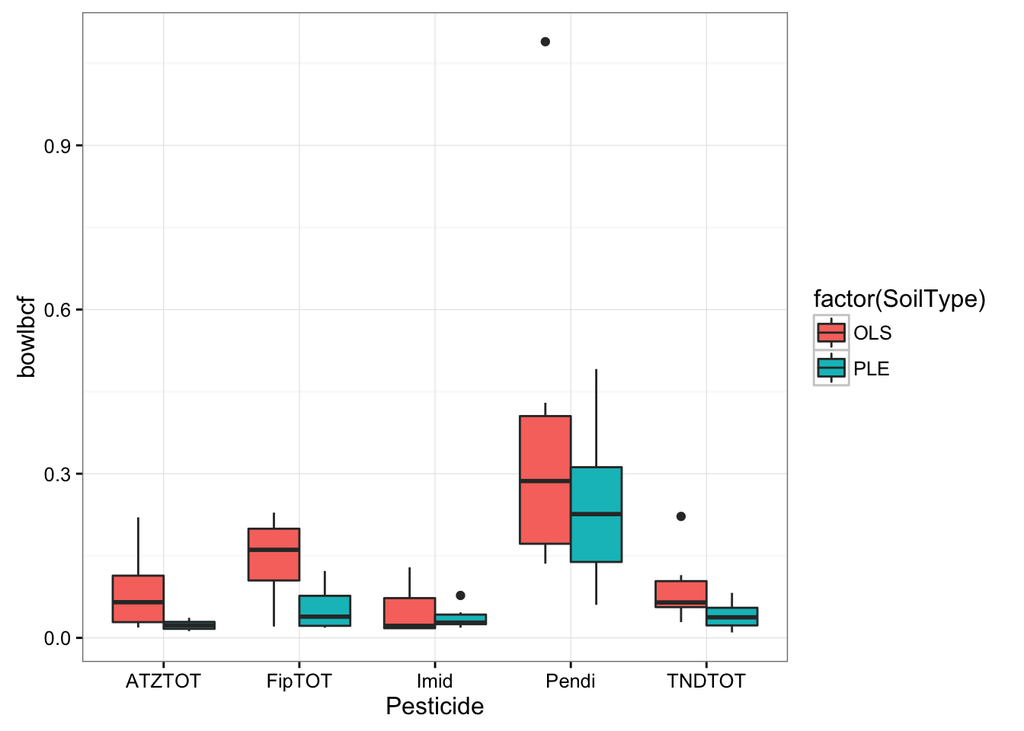

```r
qplot(Pesticide, bowlbcf, fill=factor(SoilType), data=frog.soil.total.ai, geom="boxplot", position="dodge")+theme_bw()
```

Treatment bcf results and figure. These analysis of variance results and the figure are used in the Van Meter at al. document. Context for interpretation - http://www.bodowinter.com/tutorial/bw_anova_general.pdf

Significance of soiltype: p = 0.00165, F= 10.999, df1 = 1, df2 = 53.

```r
treatbcf.total.ai.aov <- aov(treatbcf ~ Pesticide + SoilType + expKoc,
                              data = frog.soil.total.ai)
summary(treatbcf.total.ai.aov)
```

```
##             Df Sum Sq Mean Sq F value   Pr(>F)
## Pesticide    4 0.4257 0.10642  18.180 1.87e-09 ***
## SoilType     1 0.0644 0.06438  10.999  0.00165 **
## expKoc       1 0.0201 0.02012   3.438  0.06928 .
## Residuals   53 0.3102 0.00585
## ---
## Signif. codes:  0 '***' 0.001 '**' 0.01 '*' 0.05 '.' 0.1 ' ' 1
```

```r
model.tables(treatbcf.total.ai.aov)
```

```
## Tables of effects
##
##  Pesticide
## Pesticide
##   ATZTOT   FipTOT     Imid    Pendi   TNDTOT
## -0.04343 -0.00611 -0.06732  0.16376 -0.04691
##
##  SoilType
## SoilType
##      OLS      PLE
##  0.03276 -0.03276
##
##  expKoc
## expKoc
##    1.733    2.303    2.556    2.634    2.864     3.01    3.025    3.645
##  0.03371  0.01133  0.01813 -0.01133  0.00399 -0.00823  0.00823 -0.01813
##    4.242    6.425
## -0.00399 -0.03371
```

Generate figure as png for the manuscript. ggplot boxplots are different than regular R boxplots: http://docs.ggplot2.org/0.9.3.1/geom_boxplot.html

The upper and lower “hinges” correspond to the first and third quartiles (the 25th and 75th percentiles). The upper whisker extends from the hinge to the highest value that is within 1.5 * IQR of the hinge, where IQR is the inter-quartile range, or distance between the first and third quartiles. The lower whisker extends from the hinge to the lowest value within 1.5 * IQR of the hinge. Data beyond the end of the whiskers are outliers and plotted as points (as specified by Tukey).

```r
#figure 1 of Van Meter et al. manuscript
#pdf(paste(frogsoildir,"rvm2016_fig1.pdf", sep=""))
#levels(frog.soil.total.ai$Pesticide)
#levels(droplevels(frog.soil.total.ai$Pesticide))
#frog.soil.total.ai$Pesticide = factor(frog.soil.total.ai$Pesticide,levels(
#  frog.soil.total.ai$Pesticide)[c("Imid", "ATZTOT", "TNDTOT", "FipTOT", "Pendi")])
frog.soil.total.ai$Pesticide <- factor(frog.soil.total.ai$Pesticide, levels = c("Imid", "ATZTOT", "TNDTOT", "FipTOT", "Pendi"), ordered = TRUE)
#levels(frog.soil.total.ai$Pesticide) <- c("Imid", "ATZTOT", "TNDTOT", "FipTOT", "Pendi")
#png(paste(frogsoildir,"rvm2016_fig1.png", sep=""))
#tiff(paste(frogsoildir,"rvm2016_fig1.tiff", sep=""))

pesticides <- c("Imidacloprid", "Atrazine", "Triadimefon", "Fipronil", "Pendimethalin")

jpeg(paste(frogsoildir,"rvm2016_fig1.jpg", sep=""),quality=100)
  pesticides <- c("Imidacloprid", "Atrazine", "Triadimefon", "Fipronil", "Pendimethalin")
  qplot(x=Pesticide, y=treatbcf, fill=factor(SoilType), xlab="", ylab="Bioconcentration factor",
        data=frog.soil.total.ai, geom="boxplot", position="dodge") + theme_bw() +
        scale_x_discrete(breaks=c("Imid", "ATZTOT", "TNDTOT", "FipTOT", "Pendi"),  labels=pesticides)         + guides(fill=guide_legend(title="Soil type")) + theme(legend.position="top")
dev.off()
```

```r
pdf(paste(frogsoildir,"rvm2016_fig1.pdf", sep=""))
  pesticides <- c("Imidacloprid", "Atrazine", "Triadimefon", "Fipronil", "Pendimethalin")
  qplot(x=Pesticide, y=treatbcf, fill=factor(SoilType), xlab="", ylab="Bioconcentration factor",
        data=frog.soil.total.ai, geom="boxplot", position="dodge") + theme_bw() +
        scale_x_discrete(breaks=c("Imid", "ATZTOT", "TNDTOT", "FipTOT", "Pendi"),  labels=pesticides)         + guides(fill=guide_legend(title="Soil type")) + theme(legend.position="top")
dev.off()
```

For the html.

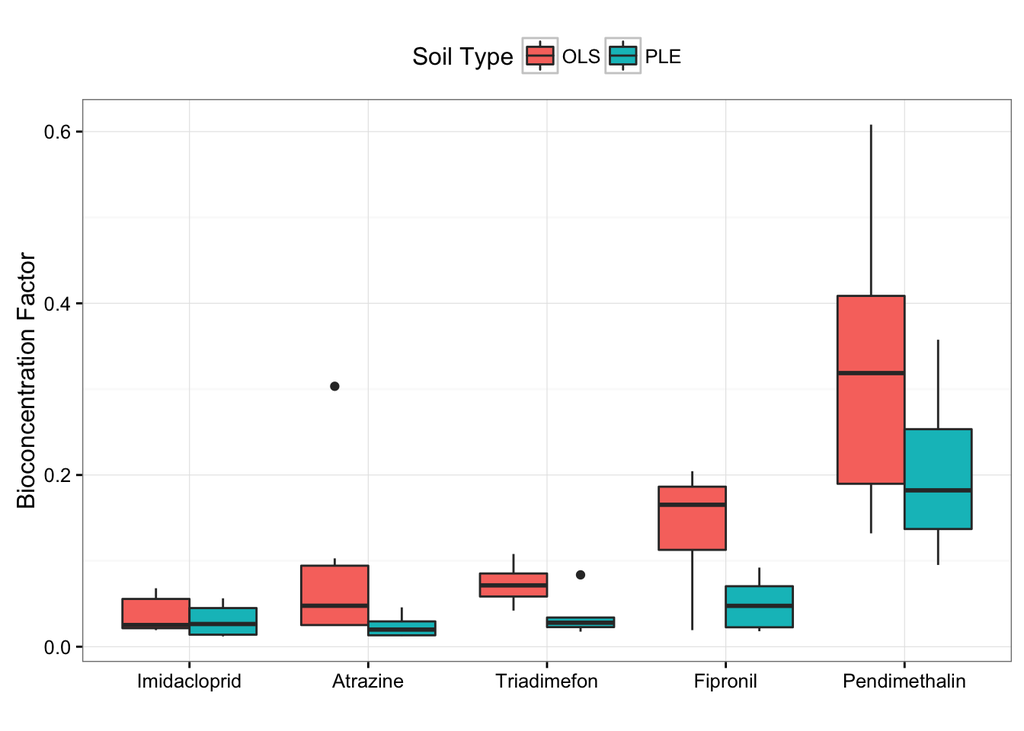

```r
  #pesticides <- c("Atrazine", "Fipronil", "Imidacloprid", "Pendimethalin", "Triadimefon")
  #reordering by kow
  pesticides <- c("Imidacloprid", "Atrazine", "Triadimefon", "Fipronil", "Pendimethalin")
  qplot(x=Pesticide, y=treatbcf, fill=factor(SoilType), xlab="", ylab="Bioconcentration Factor",
        data=frog.soil.total.ai, geom="boxplot", position="dodge") +
        theme_bw() +
        scale_x_discrete(breaks=c("Imid", "ATZTOT", "TNDTOT", "FipTOT", "Pendi"),  labels=pesticides) +
        guides(fill=guide_legend(title="Soil Type")) + theme(legend.position="top")
```

# Some additional stuff we did not use

A figure.

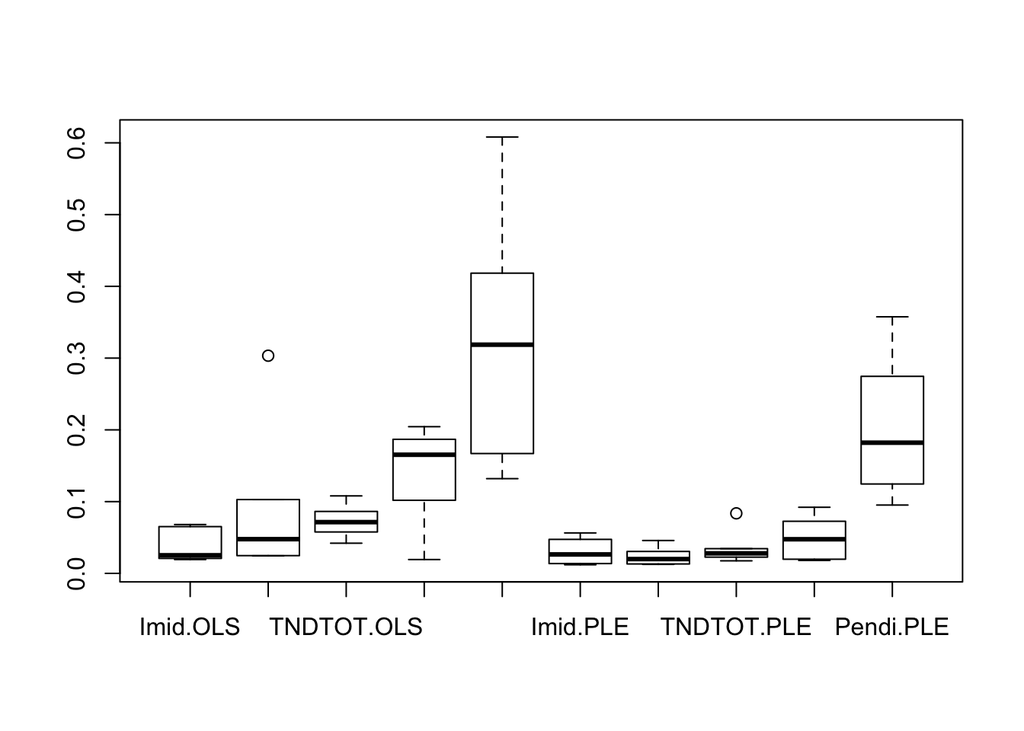

```r
boxplot(treatbcf ~ Pesticide + SoilType, data =frog.soil.total.ai)
```

We considered dropping imidacloprid for analytical reasons but it was unnecessary.

```r
# more significant if imidacloprid is dropped (but not necessary)
bowlbcf.total.noimid.aov <- aov(bowlbcf ~ Pesticide + SoilType + surface_area_total,
                                  data = frog.soil.total.noimid)
summary(bowlbcf.total.noimid.aov)
```

```
##                    Df Sum Sq Mean Sq F value   Pr(>F)
## Pesticide           3 0.5563 0.18543   8.857 0.000115 ***
## SoilType            1 0.0961 0.09613   4.592 0.037968 *
## surface_area_total  1 0.0001 0.00013   0.006 0.936840
## Residuals          42 0.8793 0.02094
## ---
## Signif. codes:  0 '***' 0.001 '**' 0.01 '*' 0.05 '.' 0.1 ' ' 1
```

```r
treatbcf.total.noimid.aov <- aov(treatbcf ~ Pesticide + SoilType + surface_area_total,
                                  data = frog.soil.total.noimid)
summary(treatbcf.total.noimid.aov)
```

```
##                    Df Sum Sq Mean Sq F value   Pr(>F)
## Pesticide           3 0.3577 0.11924  16.072 4.18e-07 ***
## SoilType            1 0.0771 0.07711  10.394  0.00245 **
## surface_area_total  1 0.0014 0.00142   0.192  0.66354
## Residuals          42 0.3116 0.00742
## ---
## Signif. codes:  0 '***' 0.001 '**' 0.01 '*' 0.05 '.' 0.1 ' ' 1
```

Tukey as anova post-hoc proxy.

```r
TukeyHSD(treatbcf.total.ai.aov)
```

```
##   Tukey multiple comparisons of means
##     95% family-wise confidence level
##
## Fit: aov(formula = treatbcf ~ Pesticide + SoilType + expKoc, data = frog.soil.total.ai)
##
## $Pesticide
##                       diff         lwr         upr     p adj
## FipTOT-ATZTOT  0.037321911 -0.05088198  0.12552581 0.7542455
## Imid-ATZTOT   -0.023891382 -0.11209528  0.06431251 0.9394943
## Pendi-ATZTOT   0.207189936  0.11898604  0.29539383 0.0000002
## TNDTOT-ATZTOT -0.003481293 -0.09168519  0.08472260 0.9999639
## Imid-FipTOT   -0.061213293 -0.14941719  0.02699060 0.2996226
## Pendi-FipTOT   0.169868025  0.08166413  0.25807192 0.0000135
## TNDTOT-FipTOT -0.040803204 -0.12900710  0.04740069 0.6884923
## Pendi-Imid     0.231081318  0.14287742  0.31928521 0.0000000
## TNDTOT-Imid    0.020410089 -0.06779381  0.10861398 0.9652483
## TNDTOT-Pendi  -0.210671229 -0.29887512 -0.12246733 0.0000001
##
## $SoilType
##                diff        lwr         upr     p adj
## PLE-OLS -0.06551572 -0.1051385 -0.02589299 0.0016508
```

Bartletts test results.

```r
#Bartlett test to test the null hypothesis of equal group variances
bartlett.test(treatbcf ~ Pesticide, data =frog.soil.total.ai)
```

```
##
##  Bartlett test of homogeneity of variances
##
## data:  treatbcf by Pesticide
## Bartlett's K-squared = 44.549, df = 4, p-value = 4.935e-09
```

```r
#no sale! for pesticides
bartlett.test(treatbcf ~ SoilType, data = frog.soil.total.ai)
```

```
##
##  Bartlett test of homogeneity of variances
##
## data:  treatbcf by SoilType
## Bartlett's K-squared = 7.5497, df = 1, p-value = 0.006002
```

```r
#also rejected for soil type, but not grouped by pesticide
```

```r
#the oneway.test( ) applies a Welch correction for nonhomogeneity
oneway.test(treatbcf ~ Pesticide + SoilType, data =frog.soil.total.ai)
```

```
##
##  One-way analysis of means (not assuming equal variances)
##
## data:  treatbcf and Pesticide + SoilType
## F = 6.0442, num df = 9.000, denom df = 20.078, p-value = 0.0003999
```

Kruskal test results.

```r
#nonparameteric kruskal test
kruskal.test(treatbcf ~ Pesticide, data =frog.soil.total.ai)
```

```
##
##  Kruskal-Wallis rank sum test
##
## data:  treatbcf by Pesticide
## Kruskal-Wallis chi-squared = 27.98, df = 4, p-value = 1.259e-05
```

```r
kruskal.test(treatbcf ~ SoilType, data =frog.soil.total.ai)
```

```
##
##  Kruskal-Wallis rank sum test
##
## data:  treatbcf by SoilType
## Kruskal-Wallis chi-squared = 7.0035, df = 1, p-value = 0.008135
```

We can also consider the pairwise t-test. For this we need the means of the pesticide treatements by soil for the test. Doesn’t make any sense.